# Prediction Assignment

A.Zhukov

December 22, 2017

## Background

Using devices such as Jawbone Up, Nike FuelBand, and Fitbit it is now possible to collect a large amount of data about personal activity relatively inexpensively. These type of devices are part of the quantified self movement – a group of enthusiasts who take measurements about themselves regularly to improve their health, to find patterns in their behavior, or because they are tech geeks. One thing that people regularly do is quantify how much of a particular activity they do, but they rarely quantify how well they do it.

## Data

The data for this project come from this source: http://groupware.les.inf.puc-rio.br/har.

### Loading datasets:

```r
data_train <- read.csv(
  "https://d396qusza40orc.cloudfront.net/predmachlearn/pml-training.csv",
  header = TRUE,
  na.strings = c("NA","#DIV/0!","")
)

data_test <- read.csv(
  "https://d396qusza40orc.cloudfront.net/predmachlearn/pml-testing.csv",
  header = TRUE,
  na.strings = c("NA","#DIV/0!","")
)
```

## Cleaning and preparing the data

Removing NA values and near zero variables from training dataset.

```r
data_train <- data_train[,-1]
data_train <- data_train[, colSums(is.na(data_train)) == 0]
nz <- nearZeroVar(data_train)
data_train <- data_train[, -nz]

# the dimension of an object
dim(data_train)
```

```
## [1] 19622    58
```

### Create training and testing sets

Using training dataset split data into training data set (80%) and a validation data set (20%). We will use it for cross validation in future.

```r
set.seed(1020) #for reproducibiliy

ptrain <- createDataPartition(y = data_train$classe, p = 0.80, list = FALSE)

set_train <- data_train[ptrain,]
set_test <- data_train[-ptrain,]
```

## Train Model

### Predicting with Decision Tree

Use the confusionMatrix function from the caret package for more statistics.

```r
fit1 <- train(classe ~., data = set_train, method = "rpart")
predict1 <- predict(fit1, set_test)
confm1 <- confusionMatrix(set_test$classe, predict1)
confm1
```

```
## Confusion Matrix and Statistics
##
##           Reference
## Prediction   A   B   C   D   E
##          A 817   2 121 173   3
##          B 164 256 147 192   0
##          C  15  10 564  95   0
##          D  25  11 211 396   0
##          E  12   5 143 156 405
##
## Overall Statistics
##
##                Accuracy : 0.6215
##                  95% CI : (0.6061, 0.6367)
##     No Information Rate : 0.3023
##     P-Value [Acc > NIR] : < 2.2e-16
##
##                   Kappa : 0.525
##  Mcnemar's Test P-Value : < 2.2e-16
##
## Statistics by Class:
##
##                      Class: A Class: B Class: C Class: D Class: E
## Sensitivity            0.7909  0.90141   0.4755   0.3913   0.9926
## Specificity            0.8965  0.86178   0.9562   0.9151   0.9101
## Pos Pred Value         0.7321  0.33729   0.8246   0.6159   0.5617
## Neg Pred Value         0.9230  0.99115   0.8080   0.8122   0.9991
## Prevalence             0.2633  0.07239   0.3023   0.2580   0.1040
## Detection Rate         0.2083  0.06526   0.1438   0.1009   0.1032
## Detection Prevalence   0.2845  0.19347   0.1744   0.1639   0.1838
## Balanced Accuracy      0.8437  0.88159   0.7159   0.6532   0.9514
```

As we see accuracy of decision tree method is mediocre: 0.6215

### Predicting with Random Forest

Now let`s examine random forest model. It`s invariant under scaling, robust and produces inspectable models.

```r
fit2 <- randomForest(classe ~., data = set_train)
predict2 <- predict(fit2, set_test, type = "class")
confm2 <- confusionMatrix(set_test$classe, predict2)
confm2
```

```
## Confusion Matrix and Statistics
##
##           Reference
## Prediction    A    B    C    D    E
##          A 1115    1    0    0    0
##          B    0  759    0    0    0
##          C    0    0  683    1    0
##          D    0    0    0  643    0
##          E    0    0    0    0  721
##
## Overall Statistics
##
##                Accuracy : 0.9995
##                  95% CI : (0.9982, 0.9999)
##     No Information Rate : 0.2842
##     P-Value [Acc > NIR] : < 2.2e-16
##
##                   Kappa : 0.9994
##  Mcnemar's Test P-Value : NA
##
## Statistics by Class:
##
##                      Class: A Class: B Class: C Class: D Class: E
## Sensitivity            1.0000   0.9987   1.0000   0.9984   1.0000
## Specificity            0.9996   1.0000   0.9997   1.0000   1.0000
## Pos Pred Value         0.9991   1.0000   0.9985   1.0000   1.0000
## Neg Pred Value         1.0000   0.9997   1.0000   0.9997   1.0000
## Prevalence             0.2842   0.1937   0.1741   0.1642   0.1838
## Detection Rate         0.2842   0.1935   0.1741   0.1639   0.1838
## Detection Prevalence   0.2845   0.1935   0.1744   0.1639   0.1838
## Balanced Accuracy      0.9998   0.9993   0.9998   0.9992   1.0000
```

This time accuracy is much better (0.9995).

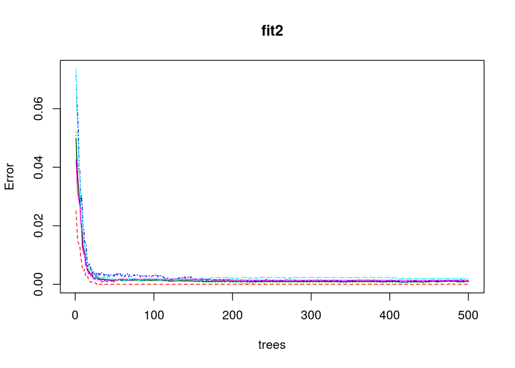

```r
plot(fit2)
```

```r
set_test$check_pred2 <- predict2 == set_test$classe
table(predict2, set_test$classe)
```

```
##
## predict2    A    B    C    D    E
##        A 1115    0    0    0    0
##        B    1  759    0    0    0
##        C    0    0  683    0    0
##        D    0    0    1  643    0
##        E    0    0    0    0  721
```

```r
data_test <- data_test[, colnames(data_test) %in% colnames(set_train)]
dt <- head(data_train,1)
dt <- rbind(dt[, -length(colnames(dt))], data_test)
result <- predict(fit2, dt[-1,], type = "class")
result
```

```
##  2  3  4  5  6  7  8  9 10 11 12 13 14 15 16 17 18 19 20 21
##  B  A  B  A  A  E  D  B  A  A  B  C  B  A  E  E  A  B  B  B
## Levels: A B C D E
```

This method give around 99% acccuracy which is much higher than previous method.

## Summary

The accuracy of the two models was compared: decision tree (0.6215) and random forest (0.9995). We can see that the random forest model had produced the highest level of accuracy as compared to the decision tree model.